# PLATAFORMA DE MONITOREO DE DATOS METEOROLOGICOS DE COCHABAMBA

SERVICIO NACIONAL DE METEOROLOGIA E HIDROLOGIA

Actualización: 2026-10-10 - 18:02 Hrs

## Heatmaps de Monitoreo Meteorológico Diario

Horario de Actualizaciones: 8:00, 8:40, 13:00, 16:00 y 18:00, los resumenes que muestran son los ultimos registros del dia hasta el momento de actualizacion. Abreviaciones: PRCP:Precipitación (mm), TMAX: Temperatura máxima (°C), TMIN: Temperatura mínima (°C), WSMAX: Velocidad de viento máximo (km/h), WSGUST: Rafaga de viento (km/h), HRMAX: Humedad relativa máxima (%) y HRMIN: Humedad relativa mínima (%).

### **PRCP**

[interactive chart not shown]

### **TMAX**

[interactive chart not shown]

### **TMIN**

[interactive chart not shown]

### **WSMAX**

[interactive chart not shown]

### **WSGUST**

[interactive chart not shown]

### **HRMAX**

[interactive chart not shown]

### **HRMIN**

[interactive chart not shown]

## Red de Estaciones Automáticas SENAMHI - COCHABAMBA

[interactive chart not shown]

### Descarga de Series Diarias y Graficas

**Nota:** Los datos y productos publicados en este repositorio tienen fines investigativos, técnicos y de apoyo a la toma de decisiones. En caso de utilizar esta información en informes, publicaciones o productos derivados, se debe citar al Servicio Nacional de Meteorología e Hidrología (SENAMHI) departamental Cochabamba como fuente oficial.

Asimismo, los datos oficiales de estaciones meteorológicas convencionales y automáticas de Bolivia pueden consultarse en: [INADHI - SENAMHI (Click Aquí)](https://senamhi.gob.bo/index.php/sysparametros)

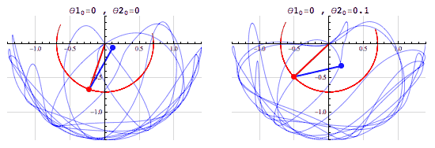

[Chaos and the Double Pendulum - Fouriest Series](https://fouriestseries.tumblr.com/post/86253333743/chaos-and-the-double-pendulum)

“La atmósfera terrestre constituye un sistema dinámico no lineal y caótico, donde pequeñas perturbaciones pueden amplificarse significativamente con el tiempo”  
Edward Lorenz